# index

2025-06-01

Name: Kim Vy Huynh Paired with: Chloé Bres-Monvoisin

####Check pwd and version

```r
setwd("E:/bioinfo/FOR/RNA_seq")
R.Version()$version.string
```

```
## [1] "R version 4.4.1 (2024-06-14 ucrt)"
```

##Read sample files and prepare a metadata file

RNA samples: All RNA samples were extracted from Scots pine roots in different treatment conditions. Each treatment has three biological replicates.

- This analysis: RNA samples were obtained from Scots pine roots incubated with Suillus luteus (Sl) - a mutualistic fungus can offer a buffering protection against pathogen attacks and promote nutrient access and water uptake by enhancing root growth through its influence on gene expression. RNA samples in the mutualistic group (Sl1, Sl2, Sl3) were analysed with RNA samples in the Control group (Ctr1, Ctr2, Ctr3).
- Comparison with other treatment group: RNA samples were obtained from Scots pine roots inoculated with Heterobasidion annousm (Ha) (one-month infection) - a pathogen can cause root and stem rot disease. RNA samples in the infected group (Ha1, Ha2, Ha3) were analysed with RNA samples in the Control group (Ctr1, Ctr2, Ctr3).

Aims of this analysis:

- Investigate the differentially expressed genes (DEGs) between two groups: Sl and Control.
- Compare the list of DEGs between different conditions analysed with the control groups: Sl and Ha.

####Install packages

```r
#if (!require("BiocManager", quietly = TRUE))
#    install.packages("BiocManager")

#BiocManager::install("DESeq2",force = TRUE)
#BiocManager::install("edgeR",force = TRUE)
```

####Read metadata file

```r
Mutualistic.targets<-read.delim("./data/fileDesc.txt")
```

####Change rownames

```r
rownames(Mutualistic.targets)<-c("Sl1","Sl2","Sl3","Ctr1","Ctr2","Ctr3")
```

####Load packages

```r
knitr::opts_chunk$set(warning = FALSE, message = FALSE)
library(edgeR)
library(DESeq2)
```

####Read each data file and check dimension

```r
Mutualistic.orig <- readDGE(Mutualistic.targets, header=F)

dim(Mutualistic.orig)
```

```
## [1] 51751     6
```

```r
head(Mutualistic.orig)
```

```
## An object of class "DGEList"
## $samples
##                files inoculation                description group lib.size
## Sl1   ./data/Sl1.txt          Sl Suillus luteus inoculation     1 17058954
## Sl2   ./data/Sl2.txt          Sl Suillus luteus inoculation     1 10329965
## Sl3   ./data/Sl3.txt          Sl Suillus luteus inoculation     1  9722676
## Ctr1 ./data/Ctr1.txt         Ctr                    Control     1 10763763
## Ctr2 ./data/Ctr2.txt         Ctr                    Control     1 10539029
## Ctr3 ./data/Ctr3.txt         Ctr                    Control     1 12251172
##      norm.factors
## Sl1             1
## Sl2             1
## Sl3             1
## Ctr1            1
## Ctr2            1
## Ctr3            1
##
## $counts
##             Samples
## Tags         Sl1 Sl2 Sl3 Ctr1 Ctr2 Ctr3
##   PITA_19277 158  81  86   90   80  329
##   PITA_36893   0   0   0    0    0    0
##   PITA_43071 228 122 145  128  133  127
##   PITA_31484   0   0   0    0    0    0
##   PITA_22913   0   0   0    0    0    0
##   PITA_43120  69  17  70   53   24   15
```

####Extract counts (dim) dataframe

```r
Mutualistic.rawCount <- Mutualistic.orig$count

dim(Mutualistic.rawCount)
```

```
## [1] 51751     6
```

```r
head(Mutualistic.rawCount)
```

```
##             Samples
## Tags         Sl1 Sl2 Sl3 Ctr1 Ctr2 Ctr3
##   PITA_19277 158  81  86   90   80  329
##   PITA_36893   0   0   0    0    0    0
##   PITA_43071 228 122 145  128  133  127
##   PITA_31484   0   0   0    0    0    0
##   PITA_22913   0   0   0    0    0    0
##   PITA_43120  69  17  70   53   24   15
```

####Build metadata

```r
sampletype <- factor(c(rep("Sl",3), rep("Ctr", 3)))

meta <- data.frame(sampletype, row.names = colnames(Mutualistic.orig$count))
colnames(Mutualistic.orig$count)
```

```
## [1] "Sl1"  "Sl2"  "Sl3"  "Ctr1" "Ctr2" "Ctr3"
```

```r
rownames(meta)
```

```
## [1] "Sl1"  "Sl2"  "Sl3"  "Ctr1" "Ctr2" "Ctr3"
```

```r
all(colnames(Mutualistic.orig$count) %in% rownames(meta))
```

```
## [1] TRUE
```

##DESeq2-normalized counts: Median of ratios method

Raw counts are normalized by DESeq2 median of ratios method.

Principle: This method normalizes sequencing depth and RNA composition (relative abundance of different RNA species) differences for RNA samples without assumming equal total read counts for all samples.

Calculation:

- Geometric mean for each gene: Geometric mean of the counts of each gene across all samples is calculated
- Set of ratios for each sample: The count for each gene is divided by that gene’s geometric mean -> a set of ratios for each sample is generated
- Size factor per sample: Median of each sample’s ratios is taken -> size factor
- Normalization: each raw count is divided by the corresponding sample’s size factor: normalized_count = raw_count / size_factor

```r
#extract raw counts
dds <- DESeqDataSetFromMatrix(Mutualistic.orig, colData = meta, design = ~ sampletype)

head(counts(dds))
```

```
##             Samples
## Tags         Sl1 Sl2 Sl3 Ctr1 Ctr2 Ctr3
##   PITA_19277 158  81  86   90   80  329
##   PITA_36893   0   0   0    0    0    0
##   PITA_43071 228 122 145  128  133  127
##   PITA_31484   0   0   0    0    0    0
##   PITA_22913   0   0   0    0    0    0
##   PITA_43120  69  17  70   53   24   15
```

####Generate size factors to correct the differences in sequencing depth across samples (normalization): normalized count(ij) = raw count(ij)/size factor(j) (i: gene idx, j: sample idx)

```r
dds <- estimateSizeFactors(dds) #calculate size factors for each sample using median ratio method
sizeFactors(dds)
```

```
##       Sl1       Sl2       Sl3      Ctr1      Ctr2      Ctr3
## 1.5321926 0.9100622 0.8699987 0.9636806 0.8834023 1.0411417
```

####Normalized counts

```r
normalized_counts <- counts(dds, normalized=TRUE)

write.csv(normalized_counts, file="./results/mutualistic_normalized_counts_DESeq2.csv")
```

##PCA plot

Principal Component Analysis (PCA): is a unsupervised, dimensionality reduction technique that transforms a large dataset (high-dimensional data) into a lower-dimensional coordinate system (often 2D), while maintaining the variability of information as much as possible via principal components. Those principal components capture the greatest variance within the data.

In this analysis, PCA is applied to assess the similarity among replicates across different samples as a sample-level quality control technique. With PCA, outliers and potential batch effects (e.g. different reagents) confounding the true biological results can be detected and visualized. The samples within two groups are expected to cluster tightly, indicating that the experimental condition is the main driver of the variation captured by principal components.

```r
library(ggplot2)
library(ggrepel)
```

Log transformation is applied to correct the skewness of normalized counts to improve the distance calculation across samples and then enhance the quality of clustering. Log2 transformation is typically used in PCA; however, regularized log (rlog) transformation is applied in this analysis instead.Rlog helps reduce the bias that might be introduced by low-count genes when using log2 transform (log2(count +1)). By log2 transform, low-count genes can exaggerate its expression values, for example:

log2(1+1)=1 and log2(0+1)=0

In raw counts, the difference between 0 and 1 is negligible. However, on the log scale, the difference of 1 unit is proportionally large. Hence, low-count genes can introduce noise into the dataset by inflating their expression value after log transformation.

```r
#Log transfromation
rld <- rlog(dds, blind=TRUE)

pdf("./results/PlotPCA_dds.pdf")
#PCA data
pcaData <- plotPCA(rld, intgroup="sampletype", returnData=TRUE)
pcaData$sample <- rownames(pcaData)
percentVar <- round(100 * attr(pcaData, "percentVar"))

#Create the plot
p <- ggplot(pcaData, aes(PC1, PC2, color=sampletype, label=sample)) +
  geom_point(size=3) +
  geom_text_repel() +  #Optional: for better label spacing
  xlab(paste0("PC1: ", percentVar[1], "% variance")) +
  ylab(paste0("PC2: ", percentVar[2], "% variance")) +
  theme_bw() +
  theme(plot.title = element_text(hjust = 0.5)) +  #Center the title
  ggtitle("PCA plot")

#Render the plot into .pdf
print(p)
dev.off()
```

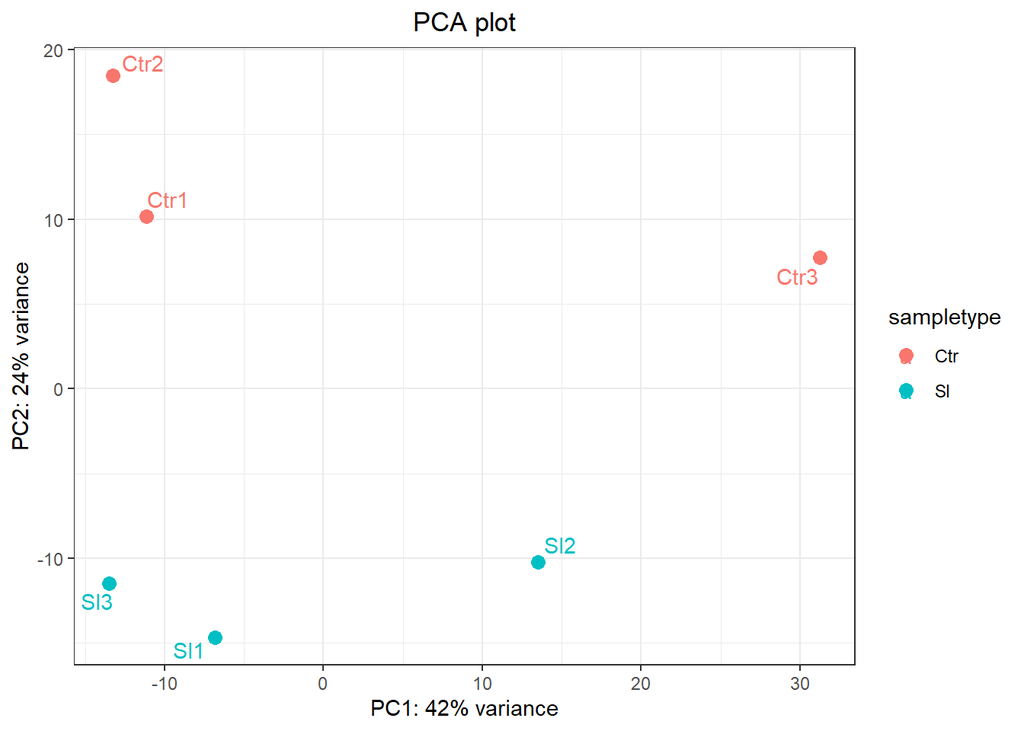

```r
print(p)
```

Results for PCA: PCA with rlog-transformed normalized counts shows distinguishable clusters for samples within Sl and control groups. The two clusters are separated along the PC2 with 24% of variance. The samples within each experimental group demonstrate a high variability, in which Sl2 and Ctr3 samples are more dispersed along the PC1 with 42% of variance compared to the others.

##Heatmap

Hierarchical Clustering Heatmap: is another sample-level quality control technique complementary to PCA. Gene expression profiles across all pairwise combinations across samples are visualized in the heatmap with their similarity and dissimilarity, in which identifies the clustering patterns and potential outliers. Samples are generally expected with high correlations with each other (>0.8), as most genes are not differentially expressed. Otherwise, below 0.8 threshold indicates a sample outlier in the dataset or potential sample contamination.

```r
#Extract rlog matrix
rld_mat <- assay(rld)

#Compute pairwise correlation values for all samples
rld_cor <- cor(rld_mat)

head(rld_cor)
```

```
##            Sl1       Sl2       Sl3      Ctr1      Ctr2      Ctr3
## Sl1  1.0000000 0.9963348 0.9974919 0.9958090 0.9959248 0.9944159
## Sl2  0.9963348 1.0000000 0.9956896 0.9950146 0.9949172 0.9968032
## Sl3  0.9974919 0.9956896 1.0000000 0.9965046 0.9961772 0.9939391
## Ctr1 0.9958090 0.9950146 0.9965046 1.0000000 0.9967342 0.9944116
## Ctr2 0.9959248 0.9949172 0.9961772 0.9967342 1.0000000 0.9940599
## Ctr3 0.9944159 0.9968032 0.9939391 0.9944116 0.9940599 1.0000000
```

```r
head(meta)
```

```
##      sampletype
## Sl1          Sl
## Sl2          Sl
## Sl3          Sl
## Ctr1        Ctr
## Ctr2        Ctr
## Ctr3        Ctr
```

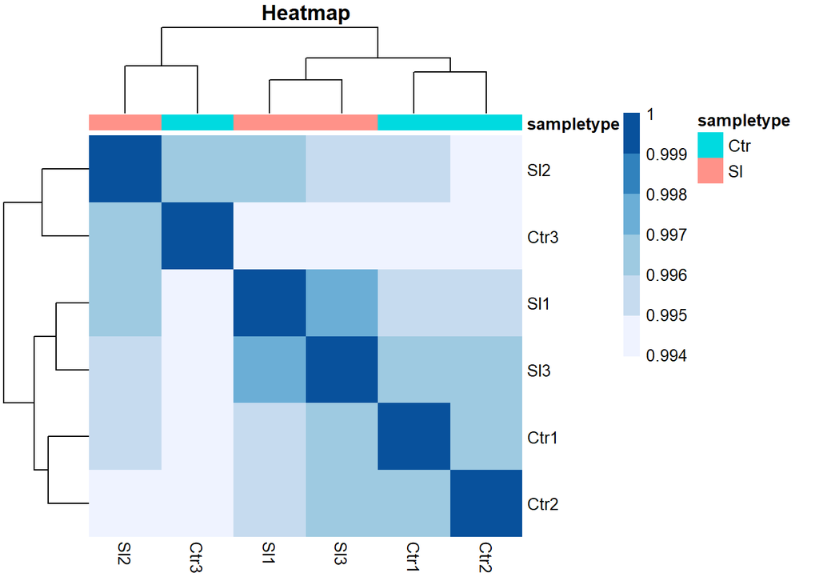

```r
#Heatmap
library(pheatmap)
library(RColorBrewer)

heat.colors <- RColorBrewer::brewer.pal(6, "Blues")

# Show heatmap interactively
pheatmap(rld_cor, annotation = meta,
         color = heat.colors, border_color=NA,
         fontsize = 10, fontsize_row = 10, height=20,
         main = "Heatmap"
        )
```

Results for heatmap: In general, all samples have high correlations with each other (>0.9). However, their gene expression profiles are not highly distinguishable, showing a blending across samples instead of separately grouping together: Ctr3 sample is blending in the Sl samples.

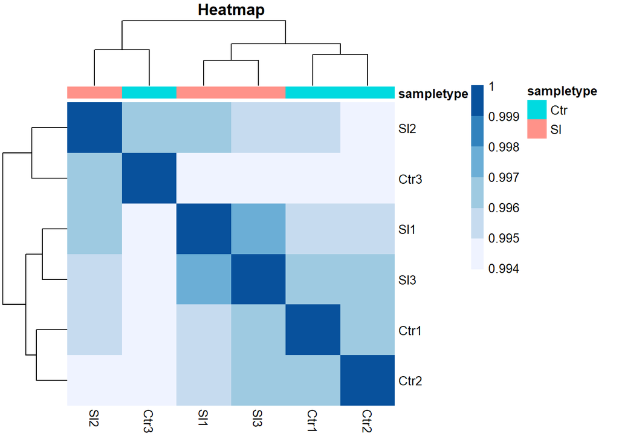

```r
#save pdf
pdf("./results/PlotHeatmap_dds.pdf")
pheatmap(rld_cor, annotation = meta,
         color = heat.colors, border_color=NA,
         fontsize = 10, fontsize_row = 10, height=20,
         main = "Heatmap"
        )
```

```r
dev.off()
```

##EdgeR: DEA

EdgeR requires raw integer read counts (un-normalized) as input -> it will perform its own normalization: TMM factors.

####Load packages

```r
library(edgeR)
options(digits=3)
library(ggplot2)
```

```r
#read file
mutualistic.targets<-read.delim("./data/fileDesc.txt")

rownames(mutualistic.targets)<-c("Sl1","Sl2","Sl3","Ctr1","Ctr2","Ctr3")

mutualistic <- readDGE(mutualistic.targets, header=F)
dim(mutualistic)
```

```
## [1] 51751     6
```

```r
head(mutualistic)
```

```
## An object of class "DGEList"
## $samples
##                files inoculation                description group lib.size
## Sl1   ./data/Sl1.txt          Sl Suillus luteus inoculation     1 17058954
## Sl2   ./data/Sl2.txt          Sl Suillus luteus inoculation     1 10329965
## Sl3   ./data/Sl3.txt          Sl Suillus luteus inoculation     1  9722676
## Ctr1 ./data/Ctr1.txt         Ctr                    Control     1 10763763
## Ctr2 ./data/Ctr2.txt         Ctr                    Control     1 10539029
## Ctr3 ./data/Ctr3.txt         Ctr                    Control     1 12251172
##      norm.factors
## Sl1             1
## Sl2             1
## Sl3             1
## Ctr1            1
## Ctr2            1
## Ctr3            1
##
## $counts
##             Samples
## Tags         Sl1 Sl2 Sl3 Ctr1 Ctr2 Ctr3
##   PITA_19277 158  81  86   90   80  329
##   PITA_36893   0   0   0    0    0    0
##   PITA_43071 228 122 145  128  133  127
##   PITA_31484   0   0   0    0    0    0
##   PITA_22913   0   0   0    0    0    0
##   PITA_43120  69  17  70   53   24   15
```

```r
mutualistic.rawCount <- mutualistic$count
head(mutualistic.rawCount)
```

```
##             Samples
## Tags         Sl1 Sl2 Sl3 Ctr1 Ctr2 Ctr3
##   PITA_19277 158  81  86   90   80  329
##   PITA_36893   0   0   0    0    0    0
##   PITA_43071 228 122 145  128  133  127
##   PITA_31484   0   0   0    0    0    0
##   PITA_22913   0   0   0    0    0    0
##   PITA_43120  69  17  70   53   24   15
```

####Raw count distribution: raw counts before filtering

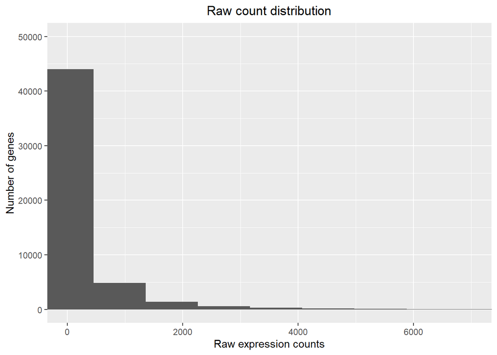

```r
ggplot(Mutualistic.rawCount) +
  geom_histogram(aes(x = Sl1), stat = "bin", bins = 200) +
  xlab("Raw expression counts") +
  ylab("Number of genes") +
  theme(plot.title = element_text(hjust = 0.5)) +  #Center the title
  ggtitle("Raw count distribution") +
  coord_cartesian(xlim = c(0, 7000), ylim = c(0, 50000)) #Adjust limits
```

Results for raw count distribution: Most raw expression counts range from 0 to 2000, with nearly 45000 genes detected within this range. A large number of genes with 0 raw count is high, so it requires a proper filter to keep relevant, sufficiently expressed genes in the downstream analysis.

```r
#save png
png("./results/count_distribution.png", res=300, height=1800, width=1800)
ggplot(Mutualistic.rawCount) +
  geom_histogram(aes(x = Sl1), stat = "bin", bins = 200) +
  xlab("Raw expression counts") +
  ylab("Number of genes") +
  theme(plot.title = element_text(hjust = 0.5)) +  #Center the title
  ggtitle("Raw count distribution") +
  coord_cartesian(xlim = c(0, 7000), ylim = c(0, 50000)) #Adjust limits
dev.off()
```

####Normalization: CPM normalized using TMM factors

Trimmed Mean of M-values (TMM): use weighted trimmed mean of the log expression ratios across samples to correct sequencing depth (library size) and RNA composition (relative abundance of different RNA species) differences.

Counts Per Million (CPM): to normalize the gene expression across samples, which only takes library size (total reads per sample) into consideration. normalized count(ij) = raw counts(ij)/total counts(j) x 10^6

CPM normalized using TMM factors can reduce the bias caused by RNA compositional differences, better reflecting the true biological variation across samples compared to CPM alone.

```r
#save raw count
write.csv(Mutualistic.rawCount, file="./results/Mutualistic.rawCounts.csv")
```

```r
#get normalized TMM before filtering
mutualistic.normCPM <- cpm(calcNormFactors(mutualistic)) #calcNormFactors: TMM

dim(mutualistic.normCPM)
```

```
## [1] 51751     6
```

```r
head(mutualistic.normCPM)
```

```
##             Samples
## Tags           Sl1   Sl2   Sl3  Ctr1  Ctr2  Ctr3
##   PITA_19277  9.14  7.75  8.69  8.16  7.90 27.60
##   PITA_36893  0.00  0.00  0.00  0.00  0.00  0.00
##   PITA_43071 13.18 11.68 14.65 11.60 13.13 10.66
##   PITA_31484  0.00  0.00  0.00  0.00  0.00  0.00
##   PITA_22913  0.00  0.00  0.00  0.00  0.00  0.00
##   PITA_43120  3.99  1.63  7.07  4.80  2.37  1.26
```

```r
#save normalized counts
write.csv(mutualistic.normCPM, file="./results/mutualistic.normCPM.csv")
```

####Filtering: Keep genes that are expressed at least 1 CPM in at least 3 libraries (samples), normally it is the number of biological replicates of smaller group

```r
mutualistic.filtered <- rowSums(cpm(mutualistic)>1) >=3

table(mutualistic.filtered)
```

```
## mutualistic.filtered
## FALSE  TRUE
## 26087 25664
```

```r
#save filtered file
mutualistic.filtered.normCPM <- mutualistic.normCPM[mutualistic.filtered,]

write.csv(mutualistic.filtered.normCPM, file="./results/mutualistic.filtered.normCPM.csv")
```

Results after filtering: 25,664 genes are kept after filtering

```r
#lib size before filtering
mutualistic$samples$lib.size
```

```
## [1] 17058954 10329965  9722676 10763763 10539029 12251172
```

```r
#lib size after filtering
Mutualistic <- mutualistic[mutualistic.filtered,]
colSums(Mutualistic$counts)
```

```
##      Sl1      Sl2      Sl3     Ctr1     Ctr2     Ctr3
## 16979210 10294682  9678018 10713161 10489408 12191523
```

```r
dim(Mutualistic)
```

```
## [1] 25664     6
```

```r
#Update the filtered lib size
Mutualistic$samples$lib.size <- colSums(Mutualistic$counts)
Mutualistic$samples
```

```
##                files inoculation                description group lib.size
## Sl1   ./data/Sl1.txt          Sl Suillus luteus inoculation     1 16979210
## Sl2   ./data/Sl2.txt          Sl Suillus luteus inoculation     1 10294682
## Sl3   ./data/Sl3.txt          Sl Suillus luteus inoculation     1  9678018
## Ctr1 ./data/Ctr1.txt         Ctr                    Control     1 10713161
## Ctr2 ./data/Ctr2.txt         Ctr                    Control     1 10489408
## Ctr3 ./data/Ctr3.txt         Ctr                    Control     1 12191523
##      norm.factors
## Sl1             1
## Sl2             1
## Sl3             1
## Ctr1            1
## Ctr2            1
## Ctr3            1
```

####Experimental design

```r
group<-factor(c('Sl','Sl','Sl',"Ctr","Ctr","Ctr"))

Mutualistic.design <- model.matrix(~group)
rownames(Mutualistic.design)<-colnames(Mutualistic$counts)
Mutualistic.design
```

```
##      (Intercept) groupSl
## Sl1            1       1
## Sl2            1       1
## Sl3            1       1
## Ctr1           1       0
## Ctr2           1       0
## Ctr3           1       0
## attr(,"assign")
## [1] 0 1
## attr(,"contrasts")
## attr(,"contrasts")$group
## [1] "contr.treatment"
```

####Sample-level quality control by multidimensional scaling (MDS)

Multidimensional Scaling (MDS): is applied as a sample-level quality control technique as PCA to cluster the different experimental groups based on their distance. Different from PCA maximizing the variance between groups by finding principal components, MDS uses pairwise distance matrix calculated by leading log-fold changes (logFC) on top genes and aims to preserve those distances as accurately as possible in a low-dimensional space.

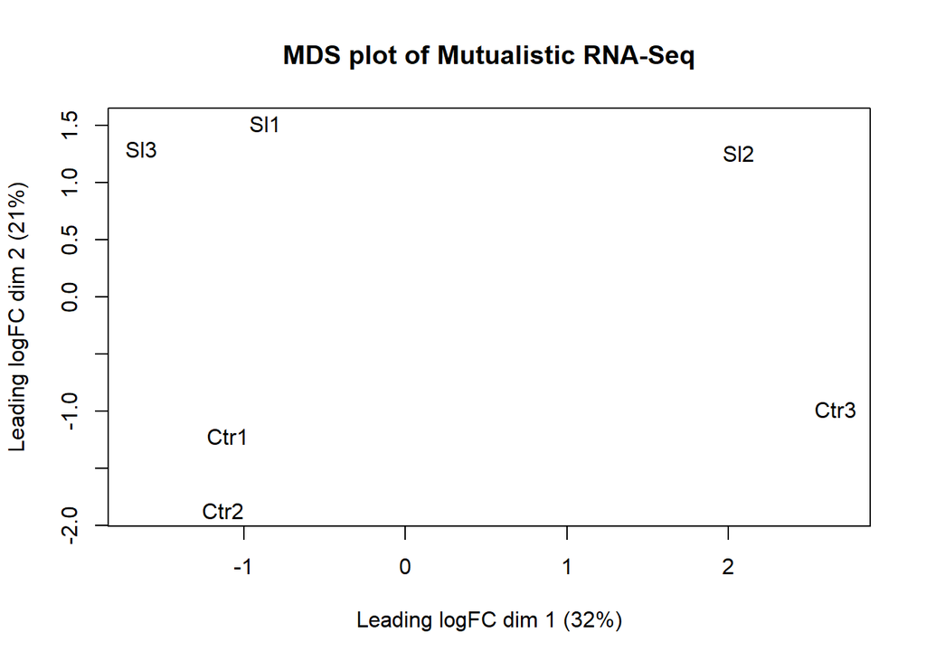

```r
plotMDS(Mutualistic, main="MDS plot of Mutualistic RNA-Seq", labels=colnames(Mutualistic$counts))
```

Results for MDS: Two experimental groups are distinctly clustered along the leading logFC dim 2 (21%), consistent with the clusters observed in PCA plot. In addition, Sl2 and Ctr3 samples demonstrate a greater dispersion (greater distance) compared to other samples within their respective groups along the leading logFC dim 1 (32%).

```r
#save png
png("./results/plotMDS.Mutualistic.png", res=300, height=1800, width=1800)
plotMDS(Mutualistic, main="MDS plot of Mutualistic RNA-Seq", labels=colnames(Mutualistic$counts))
dev.off()
```

####Estimating the common dispersion, trended dispersion, tagwwise dispersion

Biological Coefficient of Variation (BCV): to quantify the biological variability (natural differences) in gene expression among biological replicates.

Dispersion = BCV squared

BCV plot: helps assess how variability behaves across expression levels and whether dispersion estimates are reasonable

```r
#prepare the data to fit a Negative Biomial (NB) model with realistic, gene-level variability estimates

#common dispersion across all genes -> overall measure of biological variability in the dataset
Mutualistic <- estimateGLMCommonDisp(Mutualistic, Mutualistic.design)
#trended dispersion as a function of gene abundance (mean counts) -> the trend that dispersion often changes with expression level
Mutualistic <- estimateGLMTrendedDisp(Mutualistic, Mutualistic.design)
#tagwise dispersion: (gene-specific) dispersion with empirical Bayes shrinkage -> borrow info across genes to stabilize estimates: more accurate modeling of variability at the gene level
Mutualistic <- estimateGLMTagwiseDisp(Mutualistic, Mutualistic.design)
```

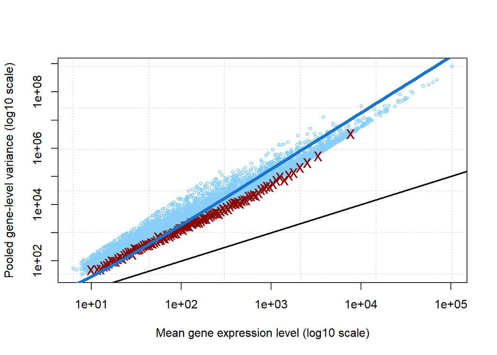

```r
#the mean-variance relationship and BCV-mean logCPM relationship
plotMeanVar(Mutualistic, show.tagwise.vars=TRUE, NBline=TRUE) #to check how well the observed gene-wise variances follow the NB expectation.
```

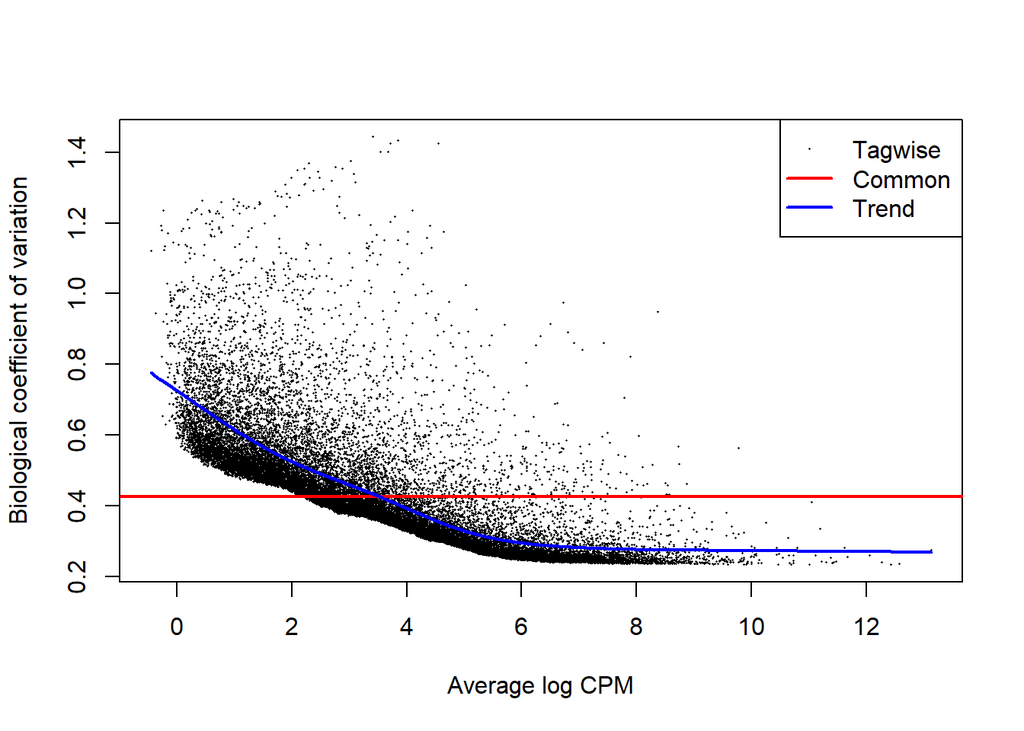

```r
plotBCV(Mutualistic) #to show how BCV changes with gene expression.
```

```r
#-> These plots help visualize how well the dispersions were estimated to ensure the differential expression results will be reliable and interpretable.
```

plotMeanVar: data points are clustered around NB line (blue), indicating a good fit with the NB model and supporting the validity of downstream differential expression analysis.

plotBCV: the trended dispersion indicates a decreasing trend with expression level, with a larger dispersion observed at low logCPM. This pattern is expected in RNAseq data, as low-expressed genes are more variable and less stable than highly-expressed genes.

####Fit DGEList and design matrix to genewise GLM

```r
Mutualistic.fit <- glmFit(Mutualistic, Mutualistic.design)
colnames(Mutualistic.fit)
```

```
## [1] "(Intercept)" "groupSl"
```

```r
lrt.Sl_vs_Ctr <- glmLRT(Mutualistic.fit, coef=2)  # to compare Sl vs Ctr (Sl_vs_Ctr)

t1 <-topTags(lrt.Sl_vs_Ctr, n=nrow(Mutualistic))
head(t1$table)
```

```
##             logFC logCPM    LR   PValue      FDR
## PITA_40477  12.07   4.53 200.6 1.56e-45 4.00e-41
## PITA_11777  10.09   2.59  89.3 3.37e-21 4.32e-17
## PITA_35366  -8.02   2.37  65.1 7.00e-16 5.99e-12
## PITA_30776 -10.53   3.00  63.6 1.53e-15 9.82e-12
## PITA_41141   9.30   1.82  60.0 9.27e-15 4.76e-11
## PITA_51743  -5.82   3.48  51.3 7.75e-13 3.32e-09
```

####Extract number of differentially expressed (DE) genes

```r
summary(decideTests(lrt.Sl_vs_Ctr, adjust.method="BH", p.value=0.05))
```

```
##        groupSl
## Down        64
## NotSig   25549
## Up          51
```

Results for DEGs: There are 115 DEGs in total (51: up-regulated genes, 64: down-regulated genes). There are more down DEGs than up DEGs.

```r
#Up-regulated genes with all differential expressed gens in treatment
nrow(subset(topTags(lrt.Sl_vs_Ctr, n=116)$table,  logFC > 0)) #top differential expressed genes: 51 + 64 + 1
```

```
## [1] 51
```

```r
lrt.Sl_vs_Ctr_UP <- subset(topTags(lrt.Sl_vs_Ctr, n=116)$table, logFC > 0)

nrow(subset(topTags(lrt.Sl_vs_Ctr, n=116)$table,  logFC < 0))
```

```
## [1] 65
```

```r
lrt.Sl_vs_Ctr_DW <- subset(topTags(lrt.Sl_vs_Ctr, n=116)$table, logFC < 0)
```

####Differentially expressed transcripts’ tag

```r
DEtags.lrt.Sl_vs_Ctr <- rownames(Mutualistic)[as.logical(decideTests(lrt.Sl_vs_Ctr, adjust.method="BH", p.value=0.05))]

#save files
write.csv(lrt.Sl_vs_Ctr_UP, file="./results/lrt.Sl_vs_Ctr_UP.csv")
write.csv(lrt.Sl_vs_Ctr_DW, file="./results/lrt.Sl_vs_Ctr_DW.csv")
```

```r
#label genes with gray color
Mutualistic.colSlvsCtr = rep('grey55', nrow(Mutualistic))

#assign color for DE transcripts
Mutualistic.colSlvsCtr[lrt.Sl_vs_Ctr$table$PValue < 0.05 & lrt.Sl_vs_Ctr$table$logFC >0 ] <- "red"
Mutualistic.colSlvsCtr[lrt.Sl_vs_Ctr$table$PValue < 0.05 & lrt.Sl_vs_Ctr$table$logFC <0 ] <- "blue"
```

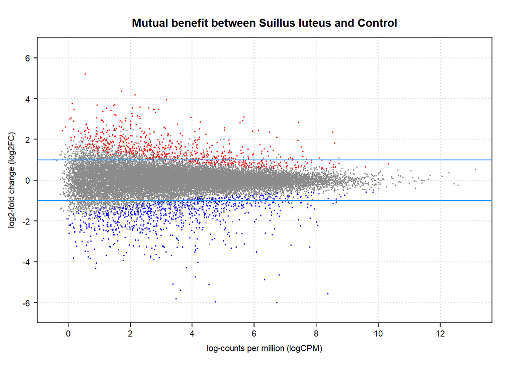

```r
#plot Smear plot
par(omi=c(0.1,0.1,0.1,0.1), las=1, cex=0.5, mgp=c(3,1,0), cex.main=1.8, cex.lab=1.4, cex.axis=1.4)
par(omi=c(0.1,0.1,0.1,0.1), las=1, cex=0.5, mgp=c(3,1,0), cex.main=1.8, cex.lab=1.4, cex.axis=1.4)
plotSmear(lrt.Sl_vs_Ctr, xlab="log-counts per million (logCPM)", ylab="log2-fold change (log2FC)", main="Mutual benefit between Suillus luteus and Control", smearWidth=0.5, pch=21, cex=0.4, deCol="red", col=Mutualistic.colSlvsCtr, ylim=c(-7,7), yaxs="i")

abline(h=c(-1,1),col="dodgerblue")
```

```r
#save png
png("./results/plotSmear.MutualisticRNAseq.png", res=300, height=1800, width=1800)
par(omi=c(0.1,0.1,0.1,0.1), las=1, cex=0.5, mgp=c(3,1,0), cex.main=1.8, cex.lab=1.4, cex.axis=1.4)
par(omi=c(0.1,0.1,0.1,0.1), las=1, cex=0.5, mgp=c(3,1,0), cex.main=1.8, cex.lab=1.4, cex.axis=1.4)
plotSmear(lrt.Sl_vs_Ctr, xlab="log-counts per million (logCPM)", ylab="log2-fold change (log2FC)", main="Mutual benefit between Suillus luteus and Control", smearWidth=0.5, pch=21, cex=0.4, deCol="red", col=Mutualistic.colSlvsCtr, ylim=c(-7,7), yaxs="i")

abline(h=c(-1,1),col="dodgerblue")
dev.off()
```

##Discussion:

1. Comparison in the number of DEGs between Sl, Ha, and control groups:

```r
#Read DEGs from two analyses
up_Sl_vs_Ctr <- read.csv("./results/lrt.Sl_vs_Ctr_UP.csv", header = TRUE)
dw_Sl_vs_Ctr <- read.csv("./results/lrt.Sl_vs_Ctr_DW.csv", header = TRUE)

up_Ha_vs_Ctr <- read.csv("./results/lrt.Ha_vs_Ctr_UP.csv", header = TRUE) #file obtained from Chloé's analysis
dw_Ha_vs_Ctr <- read.csv("./results/lrt.Ha_vs_Ctr_DW.csv", header = TRUE) #file obtained from Chloé's analysis
```

```r
cat("There are", nrow(up_Sl_vs_Ctr), "UP DEGs in Sl vs Ctr.\n")
```

```
## There are 51 UP DEGs in Sl vs Ctr.
```

```r
cat("There are", nrow(dw_Sl_vs_Ctr), "DOWN DEGs in Sl vs Ctr.\n")
```

```
## There are 65 DOWN DEGs in Sl vs Ctr.
```

```r
cat("There are", nrow(up_Ha_vs_Ctr), "UP DEGs in Ha vs Ctr.\n")
```

```
## There are 463 UP DEGs in Ha vs Ctr.
```

```r
cat("There are", nrow(dw_Ha_vs_Ctr), "DOWN DEGs in Ha vs Ctr.\n")
```

```
## There are 123 DOWN DEGs in Ha vs Ctr.
```

There are more DEGs (both up and down-regulated ones) observed in Ha infection than in Sl treatment compared to the control group.

2. Comparison in the shared DEGs between Sl, Ha, and control groups:

```r
common_up_degs <- intersect(up_Sl_vs_Ctr$X, up_Ha_vs_Ctr$X)
cat("There are", length(common_up_degs), "common UP DEGs in Sl_vs_Ctr and Ha_vs_Ctr.\n")
```

```
## There are 12 common UP DEGs in Sl_vs_Ctr and Ha_vs_Ctr.
```

```r
common_up_degs
```

```
##  [1] "PITA_40477" "PITA_32480" "PITA_24873" "PITA_34569" "PITA_33903"
##  [6] "PITA_08348" "PITA_37590" "PITA_34222" "PITA_43768" "PITA_35858"
## [11] "PITA_47065" "PITA_48756"
```

```r
common_dw_degs <- intersect(dw_Sl_vs_Ctr$X, dw_Ha_vs_Ctr$X)
cat("There are", length(common_dw_degs), "common DOWN DEGs in Sl_vs_Ctr and Ha_vs_Ctr.\n")
```

```
## There are 0 common DOWN DEGs in Sl_vs_Ctr and Ha_vs_Ctr.
```

```r
common_dw_degs
```

```
## character(0)
```

There are 12 UP DEGs overlapping in both Ha infection and Sl treatment, while there are no common DOWN DEGs between these two treatment conditions compared to the control group. In general, Ha group has a greater effect on Scots pine roots compared to Sl group, which demonstrated through the higher number of DEGs. In both treatment conditions, there are 12 UP DEGs shared among them, which are severely impacted.